# Project 1 - Feature Engineering

### Dataset

- Contians many attributes about houses
- See the data_description.txt file for a more indepth description

### Data Dictionary

- SalePrice - The property's sale price is in dollars. This is the target variable that you're trying to predict.
- MSSubClass - The building class
- MSZoning - The general zoning classification
- LotFrontage - Linear feet of street connected to property
- LotArea - Lot size in square feet
- Street - Type of road access
- Alley - Type of alley access
- LotShape - General shape of property
- LandContour - Flatness of the property
- Utilities - Type of utilities available
- LotConfig - Lot configuration
- LandSlope - Slope of property
- Neighborhood - Physical locations within Ames city limits
- Condition1 - Proximity to main road or railroad
- Condition2 - Proximity to main road or railroad (if a second is present)
- BldgType - Type of dwelling
- HouseStyle - Style of dwelling
- OverallQual - Overall material and finish quality
- OverallCond - Overall condition rating
- YearBuilt - Original construction date
- YearRemodAdd - Remodel date
- RoofStyle - Type of roof
- RoofMatl - Roof material
- Exterior1st - Exterior covering on house
- Exterior2nd - Exterior covering on house (if more than one material)
- MasVnrType - Masonry veneer type
- MasVnrArea - Masonry veneer area in square feet
- ExterQual - Exterior material quality
- ExterCond - Present condition of the material on the exterior
- Foundation - Type of foundation
- BsmtQual - Height of the basement
- BsmtCond - General condition of the basement
- BsmtExposure - Walkout or garden level basement walls
- BsmtFinType1 - Quality of the basement finished area
- BsmtFinSF1 - Type 1 finished square feet
- BsmtFinType2 - Quality of second finished area (if present)
- BsmtFinSF2 - Type 2 finished square feet
- BsmtUnfSF - Unfinished square feet of basement area
- TotalBsmtSF - Total square feet of basement area
- Heating - Type of heating
- HeatingQC - Heating quality and condition
- CentralAir - Central air conditioning
- Electrical - Electrical system
- 1stFlrSF - First Floor square feet
- 2ndFlrSF - Second floor square feet
- LowQualFinSF - Low quality finished square feet (all floors)
- GrLivArea - Above grade (ground) living area square feet
- BsmtFullBath - Basement full bathrooms
- BsmtHalfBath - Basement half bathrooms
- FullBath - Full bathrooms above grade
- HalfBath - Half bathrooms above grade
- Bedroom - Number of bedrooms above basement level
- Kitchen - Number of kitchens
- KitchenQual - Kitchen quality
- TotRmsAbvGrd - Total rooms above grade (does not include bathrooms)
- Functional - Home functionality rating
- Fireplaces - Number of fireplaces
- FireplaceQu - Fireplace quality
- GarageType - Garage location
- GarageYrBlt - Year garage was built
- GarageFinish - Interior finish of the garage
- GarageCars - Size of the garage in car capacity
- GarageArea - Size of the garage in square feet
- GarageQual - Garage quality
- GarageCond - Garage condition
- PavedDrive - Paved driveway
- WoodDeckSF - Wood deck area in square feet
- OpenPorchSF - Open porch area in square feet
- EnclosedPorch - Enclosed porch area in square feet
- 3SsnPorch - Three season porch area in square feet
- ScreenPorch - Screen porch area in square feet
- PoolArea - Pool area in square feet
- PoolQC - Pool quality
- Fence - Fence quality
- MiscFeature - Miscellaneous feature not covered in other categories
- MiscVal - $Value of miscellaneous feature
- MoSold - Month Sold
- YrSold - Year Sold
- SaleType - Type of sale
- SaleCondition - Condition of sale

### Import Libraries

```python
import numpy as np
import pandas as pd
import matplotlib.pyplot as plt
import seaborn as sns
```

### Load the dataset

```python
df = pd.read_csv("Project_Dataset_Feature_Engineering/PEP1.csv", index_col=0)
```

## Task 1 Understand the dataset

### 1.a Identify the shape of the dataset

```python
df.shape
```

```
(1460, 80)
```

### 1.a The dataset has 80 features and 1460 entries

```python
df.head()
```

| Id | MSSubClass | MSZoning | LotFrontage | LotArea | Street | Alley | LotShape | LandContour | Utilities | LotConfig | ... | PoolArea | PoolQC | Fence | MiscFeature | MiscVal | MoSold | YrSold | SaleType | SaleCondition | SalePrice |
| --- | --- | --- | --- | --- | --- | --- | --- | --- | --- | --- | --- | --- | --- | --- | --- | --- | --- | --- | --- | --- | --- |
| 1 | 60 | RL | 65.0 | 8450 | Pave | NaN | Reg | Lvl | AllPub | Inside | ... | 0 | NaN | NaN | NaN | 0 | 2 | 2008 | WD | Normal | 208500 |
| 2 | 20 | RL | 80.0 | 9600 | Pave | NaN | Reg | Lvl | AllPub | FR2 | ... | 0 | NaN | NaN | NaN | 0 | 5 | 2007 | WD | Normal | 181500 |
| 3 | 60 | RL | 68.0 | 11250 | Pave | NaN | IR1 | Lvl | AllPub | Inside | ... | 0 | NaN | NaN | NaN | 0 | 9 | 2008 | WD | Normal | 223500 |
| 4 | 70 | RL | 60.0 | 9550 | Pave | NaN | IR1 | Lvl | AllPub | Corner | ... | 0 | NaN | NaN | NaN | 0 | 2 | 2006 | WD | Abnorml | 140000 |
| 5 | 60 | RL | 84.0 | 14260 | Pave | NaN | IR1 | Lvl | AllPub | FR2 | ... | 0 | NaN | NaN | NaN | 0 | 12 | 2008 | WD | Normal | 250000 |

5 rows × 80 columns

```python
df.tail()
```

| Id | MSSubClass | MSZoning | LotFrontage | LotArea | Street | Alley | LotShape | LandContour | Utilities | LotConfig | ... | PoolArea | PoolQC | Fence | MiscFeature | MiscVal | MoSold | YrSold | SaleType | SaleCondition | SalePrice |
| --- | --- | --- | --- | --- | --- | --- | --- | --- | --- | --- | --- | --- | --- | --- | --- | --- | --- | --- | --- | --- | --- |
| 1456 | 60 | RL | 62.0 | 7917 | Pave | NaN | Reg | Lvl | AllPub | Inside | ... | 0 | NaN | NaN | NaN | 0 | 8 | 2007 | WD | Normal | 175000 |
| 1457 | 20 | RL | 85.0 | 13175 | Pave | NaN | Reg | Lvl | AllPub | Inside | ... | 0 | NaN | MnPrv | NaN | 0 | 2 | 2010 | WD | Normal | 210000 |
| 1458 | 70 | RL | 66.0 | 9042 | Pave | NaN | Reg | Lvl | AllPub | Inside | ... | 0 | NaN | GdPrv | Shed | 2500 | 5 | 2010 | WD | Normal | 266500 |
| 1459 | 20 | RL | 68.0 | 9717 | Pave | NaN | Reg | Lvl | AllPub | Inside | ... | 0 | NaN | NaN | NaN | 0 | 4 | 2010 | WD | Normal | 142125 |
| 1460 | 20 | RL | 75.0 | 9937 | Pave | NaN | Reg | Lvl | AllPub | Inside | ... | 0 | NaN | NaN | NaN | 0 | 6 | 2008 | WD | Normal | 147500 |

5 rows × 80 columns

```python
df.info()
```

```
<class 'pandas.core.frame.DataFrame'>
Int64Index: 1460 entries, 1 to 1460
Data columns (total 80 columns):
 #   Column         Non-Null Count  Dtype
---  ------         --------------  -----
 0   MSSubClass     1460 non-null   int64
 1   MSZoning       1460 non-null   object
 2   LotFrontage    1201 non-null   float64
 3   LotArea        1460 non-null   int64
 4   Street         1460 non-null   object
 5   Alley          91 non-null     object
 6   LotShape       1460 non-null   object
 7   LandContour    1460 non-null   object
 8   Utilities      1460 non-null   object
 9   LotConfig      1460 non-null   object
```

[output cut: 72 more lines]

```python
df.describe()
```

|  | MSSubClass | LotFrontage | LotArea | OverallQual | OverallCond | YearBuilt | YearRemodAdd | MasVnrArea | BsmtFinSF1 | BsmtFinSF2 | ... | WoodDeckSF | OpenPorchSF | EnclosedPorch | 3SsnPorch | ScreenPorch | PoolArea | MiscVal | MoSold | YrSold | SalePrice |
| --- | --- | --- | --- | --- | --- | --- | --- | --- | --- | --- | --- | --- | --- | --- | --- | --- | --- | --- | --- | --- | --- |
| count | 1460.000000 | 1201.000000 | 1460.000000 | 1460.000000 | 1460.000000 | 1460.000000 | 1460.000000 | 1452.000000 | 1460.000000 | 1460.000000 | ... | 1460.000000 | 1460.000000 | 1460.000000 | 1460.000000 | 1460.000000 | 1460.000000 | 1460.000000 | 1460.000000 | 1460.000000 | 1460.000000 |
| mean | 56.897260 | 70.049958 | 10516.828082 | 6.099315 | 5.575342 | 1971.267808 | 1984.865753 | 103.685262 | 443.639726 | 46.549315 | ... | 94.244521 | 46.660274 | 21.954110 | 3.409589 | 15.060959 | 2.758904 | 43.489041 | 6.321918 | 2007.815753 | 180921.195890 |
| std | 42.300571 | 24.284752 | 9981.264932 | 1.382997 | 1.112799 | 30.202904 | 20.645407 | 181.066207 | 456.098091 | 161.319273 | ... | 125.338794 | 66.256028 | 61.119149 | 29.317331 | 55.757415 | 40.177307 | 496.123024 | 2.703626 | 1.328095 | 79442.502883 |
| min | 20.000000 | 21.000000 | 1300.000000 | 1.000000 | 1.000000 | 1872.000000 | 1950.000000 | 0.000000 | 0.000000 | 0.000000 | ... | 0.000000 | 0.000000 | 0.000000 | 0.000000 | 0.000000 | 0.000000 | 0.000000 | 1.000000 | 2006.000000 | 34900.000000 |
| 25% | 20.000000 | 59.000000 | 7553.500000 | 5.000000 | 5.000000 | 1954.000000 | 1967.000000 | 0.000000 | 0.000000 | 0.000000 | ... | 0.000000 | 0.000000 | 0.000000 | 0.000000 | 0.000000 | 0.000000 | 0.000000 | 5.000000 | 2007.000000 | 129975.000000 |
| 50% | 50.000000 | 69.000000 | 9478.500000 | 6.000000 | 5.000000 | 1973.000000 | 1994.000000 | 0.000000 | 383.500000 | 0.000000 | ... | 0.000000 | 25.000000 | 0.000000 | 0.000000 | 0.000000 | 0.000000 | 0.000000 | 6.000000 | 2008.000000 | 163000.000000 |
| 75% | 70.000000 | 80.000000 | 11601.500000 | 7.000000 | 6.000000 | 2000.000000 | 2004.000000 | 166.000000 | 712.250000 | 0.000000 | ... | 168.000000 | 68.000000 | 0.000000 | 0.000000 | 0.000000 | 0.000000 | 0.000000 | 8.000000 | 2009.000000 | 214000.000000 |
| max | 190.000000 | 313.000000 | 215245.000000 | 10.000000 | 9.000000 | 2010.000000 | 2010.000000 | 1600.000000 | 5644.000000 | 1474.000000 | ... | 857.000000 | 547.000000 | 552.000000 | 508.000000 | 480.000000 | 738.000000 | 15500.000000 | 12.000000 | 2010.000000 | 755000.000000 |

8 rows × 37 columns

### 1.b Identify Variables with Null values

```python
for col in df:
    null_vals = df[col].isna().sum(axis=0)
    if null_vals:
        print(col, " has ", null_vals, " null value(s)")
```

```
LotFrontage  has  259  null value(s)
Alley  has  1369  null value(s)
MasVnrType  has  8  null value(s)
MasVnrArea  has  8  null value(s)
BsmtQual  has  37  null value(s)
BsmtCond  has  37  null value(s)
BsmtExposure  has  38  null value(s)
BsmtFinType1  has  37  null value(s)
BsmtFinType2  has  38  null value(s)
Electrical  has  1  null value(s)
FireplaceQu  has  690  null value(s)
GarageType  has  81  null value(s)
GarageYrBlt  has  81  null value(s)
GarageFinish  has  81  null value(s)
GarageQual  has  81  null value(s)
GarageCond  has  81  null value(s)
PoolQC  has  1453  null value(s)
Fence  has  1179  null value(s)
MiscFeature  has  1406  null value(s)
```

### 1.c Identify variables with unique values

```python
# for s in df:
#     print("Unique values in ",s," = ", df[s].unique())
#     print("Total number of unique values in ", s, "= ", len(df[s].unique()))
for i in df.columns:
    print (i , ":", df[i].unique(), "\n")
```

```
MSSubClass : [ 60  20  70  50 190  45  90 120  30  85  80 160  75 180  40]

MSZoning : ['RL' 'RM' 'C (all)' 'FV' 'RH']

LotFrontage : [ 65.  80.  68.  60.  84.  85.  75.  nan  51.  50.  70.  91.  72.  66.
 101.  57.  44. 110.  98.  47. 108. 112.  74. 115.  61.  48.  33.  52.
 100.  24.  89.  63.  76.  81.  95.  69.  21.  32.  78. 121. 122.  40.
 105.  73.  77.  64.  94.  34.  90.  55.  88.  82.  71. 120. 107.  92.
 134.  62.  86. 141.  97.  54.  41.  79. 174.  99.  67.  83.  43. 103.
  93.  30. 129. 140.  35.  37. 118.  87. 116. 150. 111.  49.  96.  59.
  36.  56. 102.  58.  38. 109. 130.  53. 137.  45. 106. 104.  42.  39.
 144. 114. 128. 149. 313. 168. 182. 138. 160. 152. 124. 153.  46.]

LotArea : [ 8450  9600 11250 ... 17217 13175  9717]

Street : ['Pave' 'Grvl']

Alley : [nan 'Grvl' 'Pave']

LotShape : ['Reg' 'IR1' 'IR2' 'IR3']

LandContour : ['Lvl' 'Bnk' 'Low' 'HLS']

Utilities : ['AllPub' 'NoSeWa']

LotConfig : ['Inside' 'FR2' 'Corner' 'CulDSac' 'FR3']

LandSlope : ['Gtl' 'Mod' 'Sev']

Neighborhood : ['CollgCr' 'Veenker' 'Crawfor' 'NoRidge' 'Mitchel' 'Somerst' 'NWAmes'
 'OldTown' 'BrkSide' 'Sawyer' 'NridgHt' 'mes' 'SawyerW' 'IDOTRR' 'MeadowV'
 'Edwards' 'Timber' 'Gilbert' 'StoneBr' 'ClearCr' 'NPkVill' 'Blmngtn'
 'BrDale' 'SWISU' 'Blueste']

Condition1 : ['Norm' 'Feedr' 'PosN' 'Artery' 'RRAe' 'RRNn' 'RRAn' 'PosA' 'RRNe']

Condition2 : ['Norm' 'Artery' 'RRNn' 'Feedr' 'PosN' 'PosA' 'RRAn' 'RRAe']

BldgType : ['1Fam' '2fmCon' 'Duplex' 'TwnhsE' 'Twnhs']

```

[output cut: 624 more lines]

```
  99500 182000 167500  85500 178400 336000 159895 255900 117000 395192
 195000 197000 348000 173900 337500 121600 206000 232000 136905 119200
 227000 203000 213490 194000 287000 293077 310000 119750  84000 315500
 262280 278000 139600 556581  84900 176485 200141 185850 328000 167900
 151400  91500 138800 155900  83500 252000  92900 176432 274725 134500
 184100 133700 118400 212900 163900 259000 239500  94000 424870 174500
 116900 201800 218000 235128 108959 233170 245350 625000 171900 154900
 392500 745000 186700 104900 262000 219210 116050 271900 229456  80500
 137900 367294 101800 138887 265900 248328 465000 186500 169900 171750
 294000 165400 301500  99900 128900 183900 378500 381000 185750  68400
 150500 281000 333168 206900 295493 111000 156500  72500  52500 155835
 108500 283463 410000 156932 144152 216000 274300 466500  58500 237500
 377500 246578 281213 137450 193879 282922 257000 223000 274970 182900
 192140 143750  64500 394617 149700 149300 121000 179600  92000 287090
 266500 142125 147500]
```

## 2. Generate a separate dataset for numerical and categorical variables

```python
df_numerical = df._get_numeric_data()
df_numerical
```

| Id | MSSubClass | LotFrontage | LotArea | OverallQual | OverallCond | YearBuilt | YearRemodAdd | MasVnrArea | BsmtFinSF1 | BsmtFinSF2 | ... | WoodDeckSF | OpenPorchSF | EnclosedPorch | 3SsnPorch | ScreenPorch | PoolArea | MiscVal | MoSold | YrSold | SalePrice |
| --- | --- | --- | --- | --- | --- | --- | --- | --- | --- | --- | --- | --- | --- | --- | --- | --- | --- | --- | --- | --- | --- |
| 1 | 60 | 65.0 | 8450 | 7 | 5 | 2003 | 2003 | 196.0 | 706 | 0 | ... | 0 | 61 | 0 | 0 | 0 | 0 | 0 | 2 | 2008 | 208500 |
| 2 | 20 | 80.0 | 9600 | 6 | 8 | 1976 | 1976 | 0.0 | 978 | 0 | ... | 298 | 0 | 0 | 0 | 0 | 0 | 0 | 5 | 2007 | 181500 |
| 3 | 60 | 68.0 | 11250 | 7 | 5 | 2001 | 2002 | 162.0 | 486 | 0 | ... | 0 | 42 | 0 | 0 | 0 | 0 | 0 | 9 | 2008 | 223500 |
| 4 | 70 | 60.0 | 9550 | 7 | 5 | 1915 | 1970 | 0.0 | 216 | 0 | ... | 0 | 35 | 272 | 0 | 0 | 0 | 0 | 2 | 2006 | 140000 |
| 5 | 60 | 84.0 | 14260 | 8 | 5 | 2000 | 2000 | 350.0 | 655 | 0 | ... | 192 | 84 | 0 | 0 | 0 | 0 | 0 | 12 | 2008 | 250000 |
| ... | ... | ... | ... | ... | ... | ... | ... | ... | ... | ... | ... | ... | ... | ... | ... | ... | ... | ... | ... | ... | ... |
| 1456 | 60 | 62.0 | 7917 | 6 | 5 | 1999 | 2000 | 0.0 | 0 | 0 | ... | 0 | 40 | 0 | 0 | 0 | 0 | 0 | 8 | 2007 | 175000 |
| 1457 | 20 | 85.0 | 13175 | 6 | 6 | 1978 | 1988 | 119.0 | 790 | 163 | ... | 349 | 0 | 0 | 0 | 0 | 0 | 0 | 2 | 2010 | 210000 |
| 1458 | 70 | 66.0 | 9042 | 7 | 9 | 1941 | 2006 | 0.0 | 275 | 0 | ... | 0 | 60 | 0 | 0 | 0 | 0 | 2500 | 5 | 2010 | 266500 |
| 1459 | 20 | 68.0 | 9717 | 5 | 6 | 1950 | 1996 | 0.0 | 49 | 1029 | ... | 366 | 0 | 112 | 0 | 0 | 0 | 0 | 4 | 2010 | 142125 |
| 1460 | 20 | 75.0 | 9937 | 5 | 6 | 1965 | 1965 | 0.0 | 830 | 290 | ... | 736 | 68 | 0 | 0 | 0 | 0 | 0 | 6 | 2008 | 147500 |

1460 rows × 37 columns

```python
df_categorical = df[list(set(df.columns) - set(df_numerical.columns))]
df_categorical
```

| Id | Heating | Foundation | SaleCondition | Fence | BsmtFinType2 | LotShape | Alley | GarageQual | GarageCond | MiscFeature | ... | BsmtFinType1 | LandContour | Functiol | BldgType | Utilities | PavedDrive | HeatingQC | GarageFinish | ExterQual | HouseStyle |
| --- | --- | --- | --- | --- | --- | --- | --- | --- | --- | --- | --- | --- | --- | --- | --- | --- | --- | --- | --- | --- | --- |
| 1 | GasA | PConc | Normal | NaN | Unf | Reg | NaN | TA | TA | NaN | ... | GLQ | Lvl | Typ | 1Fam | AllPub | Y | Ex | RFn | Gd | 2Story |
| 2 | GasA | CBlock | Normal | NaN | Unf | Reg | NaN | TA | TA | NaN | ... | ALQ | Lvl | Typ | 1Fam | AllPub | Y | Ex | RFn | TA | 1Story |
| 3 | GasA | PConc | Normal | NaN | Unf | IR1 | NaN | TA | TA | NaN | ... | GLQ | Lvl | Typ | 1Fam | AllPub | Y | Ex | RFn | Gd | 2Story |
| 4 | GasA | BrkTil | Abnorml | NaN | Unf | IR1 | NaN | TA | TA | NaN | ... | ALQ | Lvl | Typ | 1Fam | AllPub | Y | Gd | Unf | TA | 2Story |
| 5 | GasA | PConc | Normal | NaN | Unf | IR1 | NaN | TA | TA | NaN | ... | GLQ | Lvl | Typ | 1Fam | AllPub | Y | Ex | RFn | Gd | 2Story |
| ... | ... | ... | ... | ... | ... | ... | ... | ... | ... | ... | ... | ... | ... | ... | ... | ... | ... | ... | ... | ... | ... |
| 1456 | GasA | PConc | Normal | NaN | Unf | Reg | NaN | TA | TA | NaN | ... | Unf | Lvl | Typ | 1Fam | AllPub | Y | Ex | RFn | TA | 2Story |
| 1457 | GasA | CBlock | Normal | MnPrv | Rec | Reg | NaN | TA | TA | NaN | ... | ALQ | Lvl | Min1 | 1Fam | AllPub | Y | TA | Unf | TA | 1Story |
| 1458 | GasA | Stone | Normal | GdPrv | Unf | Reg | NaN | TA | TA | Shed | ... | GLQ | Lvl | Typ | 1Fam | AllPub | Y | Ex | RFn | Ex | 2Story |
| 1459 | GasA | CBlock | Normal | NaN | Rec | Reg | NaN | TA | TA | NaN | ... | GLQ | Lvl | Typ | 1Fam | AllPub | Y | Gd | Unf | TA | 1Story |
| 1460 | GasA | CBlock | Normal | NaN | LwQ | Reg | NaN | TA | TA | NaN | ... | BLQ | Lvl | Typ | 1Fam | AllPub | Y | Gd | Fin | Gd | 1Story |

1460 rows × 43 columns

## 3. EDA of numerical variables:

### 3.a Missing value treatment

```python
for col in df_numerical:
    null_vals = df_numerical[col].isna().sum(axis=0)
    if null_vals:
        print(col, " has ", null_vals, " null value(s)")
```

```
LotFrontage  has  259  null value(s)
MasVnrArea  has  8  null value(s)
GarageYrBlt  has  81  null value(s)
```

```python
percentage_of_missing_values = (df_numerical.isna().sum()/df_numerical.shape[0])*100
percentage_of_missing_values
```

```
MSSubClass        0.000000
LotFrontage      17.739726
LotArea           0.000000
OverallQual       0.000000
OverallCond       0.000000
YearBuilt         0.000000
YearRemodAdd      0.000000
MasVnrArea        0.547945
BsmtFinSF1        0.000000
BsmtFinSF2        0.000000
BsmtUnfSF         0.000000
TotalBsmtSF       0.000000
1stFlrSF          0.000000
2ndFlrSF          0.000000
LowQualFinSF      0.000000
GrLivArea         0.000000
BsmtFullBath      0.000000
BsmtHalfBath      0.000000
FullBath          0.000000
HalfBath          0.000000
BedroomAbvGr      0.000000
KitchebvGr        0.000000
TotRmsAbvGrd      0.000000
Fireplaces        0.000000
GarageYrBlt       5.547945
GarageCars        0.000000
GarageArea        0.000000
WoodDeckSF        0.000000
OpenPorchSF       0.000000
EnclosedPorch     0.000000
3SsnPorch         0.000000
ScreenPorch       0.000000
PoolArea          0.000000
MiscVal           0.000000
MoSold            0.000000
YrSold            0.000000
SalePrice         0.000000
dtype: float64
```

### Observations:

```python
print("Shape before dropping = ", df_numerical.shape)
df_numerical = df_numerical.dropna()
print("Shape after dropping = ", df_numerical.shape)
```

```
Shape before dropping =  (1460, 37)
Shape after dropping =  (1121, 37)
```

### 3.b Identify the skewness and distribution

```python
df_numerical.skew()
```

```
MSSubClass        1.412907
LotFrontage       2.251197
LotArea          15.608113
OverallQual       0.287800
OverallCond       0.846451
YearBuilt        -0.618350
YearRemodAdd     -0.565757
MasVnrArea        2.706945
BsmtFinSF1        1.934077
BsmtFinSF2        4.399358
BsmtUnfSF         0.875774
TotalBsmtSF       1.754916
1stFlrSF          1.363783
2ndFlrSF          0.807411
LowQualFinSF     10.020823
GrLivArea         1.549961
BsmtFullBath      0.568804
BsmtHalfBath      4.107874
FullBath          0.015822
HalfBath          0.638178
BedroomAbvGr      0.074427
KitchebvGr        4.822542
TotRmsAbvGrd      0.723117
Fireplaces        0.643698
GarageYrBlt      -0.641738
GarageCars        0.206017
GarageArea        0.733894
WoodDeckSF        1.549793
OpenPorchSF       2.403928
EnclosedPorch     3.173250
3SsnPorch        10.854868
ScreenPorch       4.019111
PoolArea         13.783823
MiscVal           9.699989
MoSold            0.173039
YrSold            0.106730
SalePrice         1.933615
dtype: float64
```

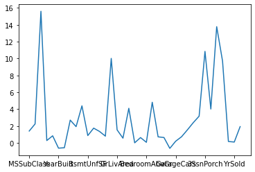

```python
df_numerical.skew().plot()
```

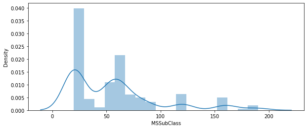

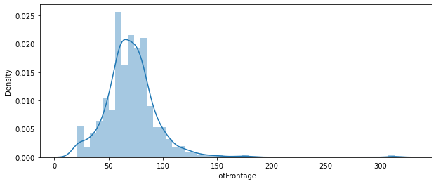

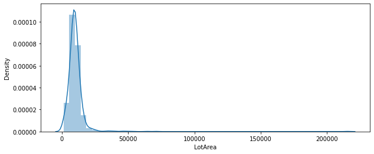

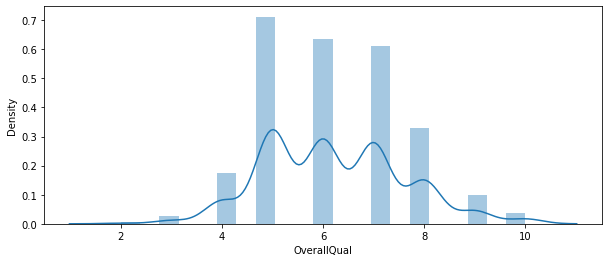

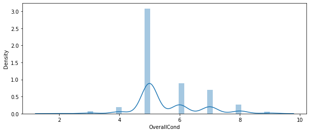

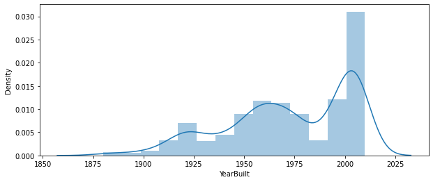

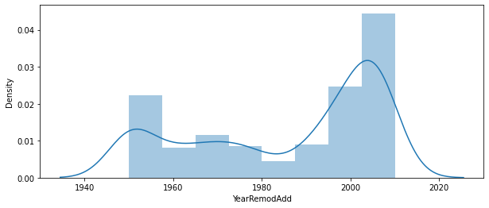

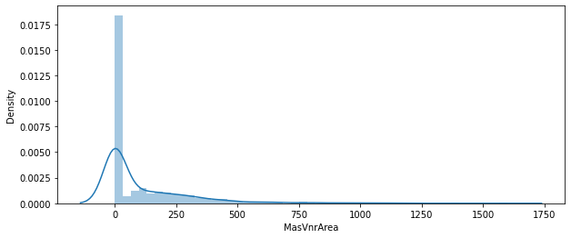

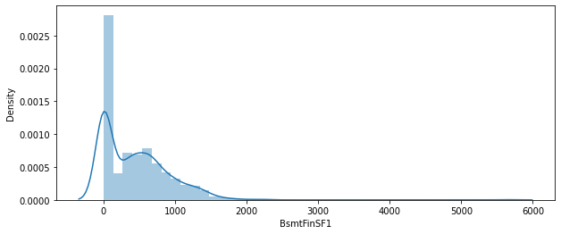

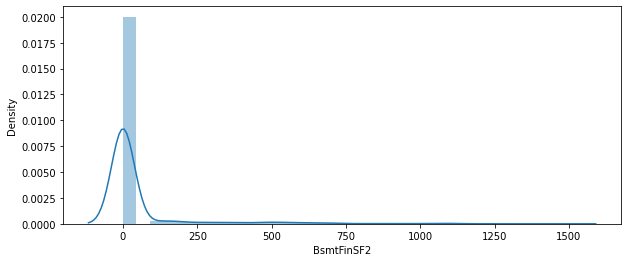

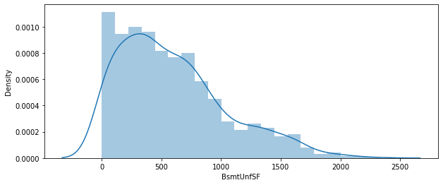

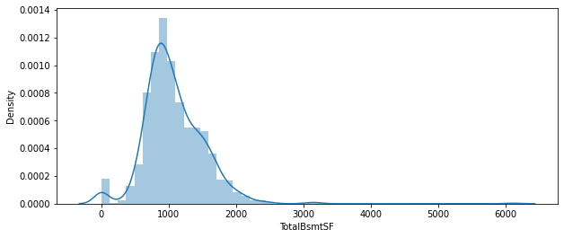

[25 more figures not shown]

```python
for col in df_numerical:
    plt.figure(figsize=(10,4))
    sns.distplot(df_numerical[col], hist=True, kde=True)
    plt.show()
```

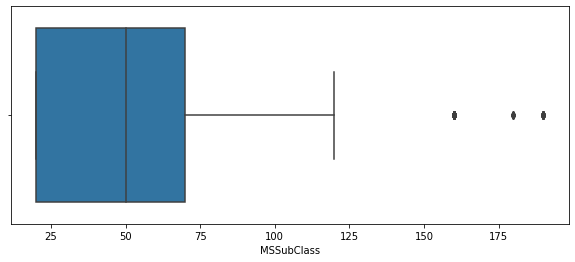

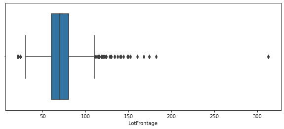

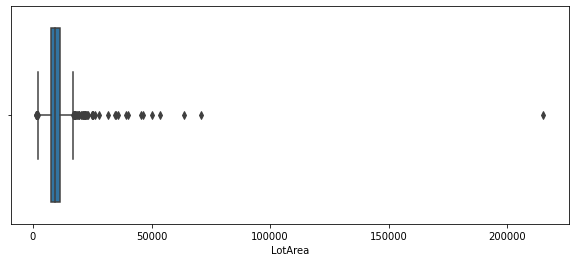

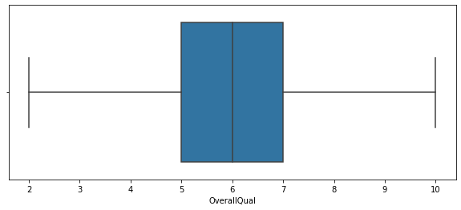

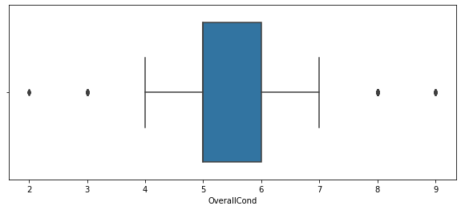

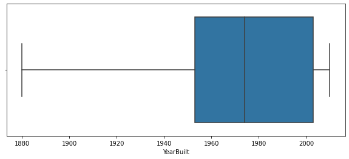

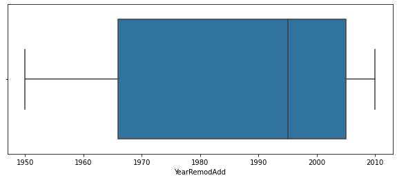

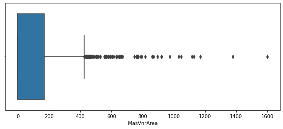

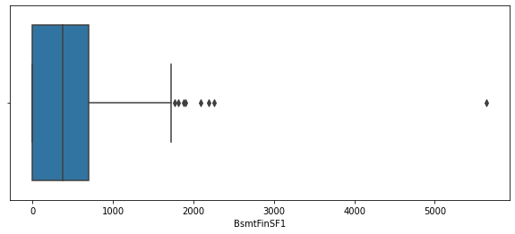

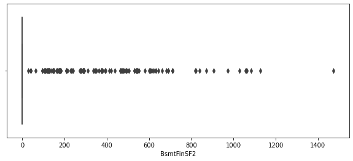

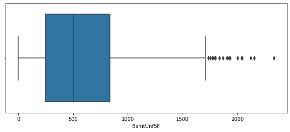

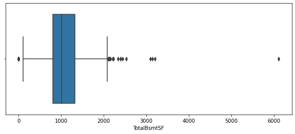

[25 more figures not shown]

```python
for col in df_numerical:
    plt.figure(figsize=(10,4))
    sns.boxplot(x=df_numerical[col],data = df_numerical)
    plt.show()
```

### 3.c Identify significant variables using a correlation matrix

```python
df_numerical.corr()
```

|  | MSSubClass | LotFrontage | LotArea | OverallQual | OverallCond | YearBuilt | YearRemodAdd | MasVnrArea | BsmtFinSF1 | BsmtFinSF2 | ... | WoodDeckSF | OpenPorchSF | EnclosedPorch | 3SsnPorch | ScreenPorch | PoolArea | MiscVal | MoSold | YrSold | SalePrice |
| --- | --- | --- | --- | --- | --- | --- | --- | --- | --- | --- | --- | --- | --- | --- | --- | --- | --- | --- | --- | --- | --- |
| MSSubClass | 1.000000 | -0.386940 | -0.198096 | 0.029522 | -0.087859 | 0.025800 | 0.006645 | 0.040240 | -0.070389 | -0.075439 | ... | -0.017988 | 0.004054 | -0.017790 | -0.039739 | -0.021789 | 0.003166 | -0.040689 | -0.027170 | -0.012448 | -0.088032 |
| LotFrontage | -0.386940 | 1.000000 | 0.421184 | 0.241322 | -0.046312 | 0.109726 | 0.086414 | 0.189969 | 0.241352 | 0.049305 | ... | 0.082166 | 0.161815 | 0.014261 | 0.069716 | 0.035906 | 0.211746 | 0.001471 | 0.018815 | 0.013267 | 0.344270 |
| LotArea | -0.198096 | 0.421184 | 1.000000 | 0.167525 | -0.034348 | 0.029205 | 0.026848 | 0.106115 | 0.230441 | 0.138234 | ... | 0.133576 | 0.099170 | -0.023631 | 0.012520 | 0.072517 | 0.109147 | 0.012790 | 0.008998 | -0.006904 | 0.299962 |
| OverallQual | 0.029522 | 0.241322 | 0.167525 | 1.000000 | -0.163157 | 0.589385 | 0.570757 | 0.423988 | 0.249500 | -0.068506 | ... | 0.282512 | 0.340679 | -0.144344 | 0.017331 | 0.055296 | 0.080131 | -0.062064 | 0.079895 | -0.008903 | 0.797881 |
| OverallCond | -0.087859 | -0.046312 | -0.034348 | -0.163157 | 1.000000 | -0.426462 | 0.039402 | -0.166762 | -0.054788 | 0.042314 | ... | -0.010835 | -0.076273 | 0.062748 | -0.006861 | 0.087030 | -0.023566 | 0.119772 | -0.014236 | 0.041003 | -0.124391 |
| YearBuilt | 0.025800 | 0.109726 | 0.029205 | 0.589385 | -0.426462 | 1.000000 | 0.623171 | 0.332190 | 0.236941 | -0.054414 | ... | 0.238548 | 0.235432 | -0.392693 | 0.027948 | -0.063694 | 0.006717 | -0.096973 | 0.013784 | -0.004585 | 0.525394 |
| YearRemodAdd | 0.006645 | 0.086414 | 0.026848 | 0.570757 | 0.039402 | 0.623171 | 1.000000 | 0.193376 | 0.120774 | -0.057024 | ... | 0.244602 | 0.260521 | -0.214115 | 0.026304 | -0.034288 | 0.019307 | -0.040420 | 0.026884 | 0.041302 | 0.521253 |
| MasVnrArea | 0.040240 | 0.189969 | 0.106115 | 0.423988 | -0.166762 | 0.332190 | 0.193376 | 1.000000 | 0.285331 | -0.075261 | ... | 0.174649 | 0.129532 | -0.116832 | 0.022331 | 0.052646 | 0.021648 | -0.054044 | 0.015850 | -0.017569 | 0.488658 |
| BsmtFinSF1 | -0.070389 | 0.241352 | 0.230441 | 0.249500 | -0.054788 | 0.236941 | 0.120774 | 0.285331 | 1.000000 | -0.035780 | ... | 0.206246 | 0.127900 | -0.105410 | 0.021831 | 0.059635 | 0.194349 | 0.003027 | -0.015281 | 0.010224 | 0.390301 |
| BsmtFinSF2 | -0.075439 | 0.049305 | 0.138234 | -0.068506 | 0.042314 | -0.054414 | -0.057024 | -0.075261 | -0.035780 | 1.000000 | ... | 0.032338 | 0.010518 | 0.047221 | -0.030848 | 0.067899 | 0.061212 | 0.014290 | -0.036101 | 0.036395 | -0.028021 |
| BsmtUnfSF | -0.145582 | 0.115306 | 0.011288 | 0.322663 | -0.148630 | 0.177545 | 0.199893 | 0.110067 | -0.502225 | -0.220190 | ... | 0.005391 | 0.151572 | -0.035791 | 0.021502 | -0.006398 | -0.053894 | -0.038915 | 0.027068 | -0.026736 | 0.213129 |
| TotalBsmtSF | -0.247781 | 0.387620 | 0.302554 | 0.563960 | -0.192762 | 0.409134 | 0.308696 | 0.384434 | 0.530917 | 0.094079 | ... | 0.233664 | 0.291286 | -0.130223 | 0.033743 | 0.080259 | 0.171489 | -0.031076 | -0.001498 | -0.003377 | 0.615612 |
| 1stFlrSF | -0.252249 | 0.451085 | 0.329679 | 0.514453 | -0.164251 | 0.308875 | 0.281436 | 0.363209 | 0.468020 | 0.073090 | ... | 0.237628 | 0.244846 | -0.113595 | 0.037505 | 0.087580 | 0.151761 | -0.030909 | 0.027731 | 0.000420 | 0.607969 |
| 2ndFlrSF | 0.319328 | 0.075004 | 0.074612 | 0.273197 | 0.005985 | -0.011621 | 0.103627 | 0.180567 | -0.120823 | -0.111850 | ... | 0.114480 | 0.203460 | 0.076479 | -0.027471 | 0.047039 | 0.094076 | 0.027047 | 0.041485 | -0.028010 | 0.306879 |
| LowQualFinSF | 0.024704 | 0.011148 | 0.020039 | -0.008118 | 0.048720 | -0.164359 | -0.053479 | -0.062930 | -0.050824 | 0.015459 | ... | -0.017374 | 0.032968 | 0.060988 | 0.002171 | 0.056472 | 0.099089 | 0.015231 | -0.026645 | -0.016253 | -0.001482 |
| GrLivArea | 0.083365 | 0.396306 | 0.307164 | 0.607466 | -0.112231 | 0.204967 | 0.290050 | 0.414024 | 0.239888 | -0.038541 | ... | 0.269703 | 0.353534 | -0.014874 | 0.004823 | 0.108453 | 0.198551 | 0.001067 | 0.053071 | -0.024436 | 0.705154 |
| BsmtFullBath | -0.014681 | 0.118088 | 0.179052 | 0.126834 | -0.060943 | 0.182800 | 0.111897 | 0.110379 | 0.651727 | 0.168559 | ... | 0.157510 | 0.081623 | -0.042631 | -0.007893 | 0.023857 | 0.104349 | 0.027641 | -0.030282 | 0.058467 | 0.236737 |
| BsmtHalfBath | 0.012310 | 0.000434 | -0.014282 | -0.053283 | 0.122960 | -0.049645 | -0.017049 | -0.007035 | 0.061963 | 0.059148 | ... | 0.054066 | -0.060347 | 0.000854 | 0.056402 | -0.007323 | 0.031503 | -0.010947 | 0.027037 | -0.049851 | -0.036513 |
| FullBath | 0.131278 | 0.185785 | 0.129073 | 0.576875 | -0.229848 | 0.500495 | 0.467563 | 0.285561 | 0.052313 | -0.082945 | ... | 0.215028 | 0.286248 | -0.164548 | 0.032051 | 0.001415 | 0.049608 | -0.029397 | 0.072305 | -0.000015 | 0.566627 |
| HalfBath | 0.203971 | 0.045678 | 0.045183 | 0.251690 | -0.079023 | 0.220000 | 0.164203 | 0.195273 | 0.007545 | -0.031685 | ... | 0.114153 | 0.194016 | -0.080586 | -0.002422 | 0.073306 | 0.042099 | -0.055379 | -0.007637 | -0.020875 | 0.268560 |
| BedroomAbvGr | -0.032971 | 0.270404 | 0.137269 | 0.094882 | 0.004643 | -0.061580 | -0.075812 | 0.114310 | -0.104275 | 0.008975 | ... | 0.077918 | 0.079124 | 0.040681 | -0.029136 | 0.063660 | 0.073361 | 0.046523 | 0.031268 | -0.026035 | 0.166814 |
| KitchebvGr | 0.266012 | -0.003546 | -0.018942 | -0.178735 | -0.092644 | -0.171920 | -0.181803 | -0.023647 | -0.062920 | -0.047693 | ... | -0.099832 | -0.060133 | 0.013411 | -0.023299 | -0.050308 | -0.015114 | -0.000640 | 0.030001 | 0.028463 | -0.140497 |
| TotRmsAbvGrd | 0.047209 | 0.348421 | 0.237918 | 0.451008 | -0.096901 | 0.121417 | 0.181995 | 0.315604 | 0.080207 | -0.054900 | ... | 0.190527 | 0.246714 | -0.031651 | -0.023904 | 0.070894 | 0.093387 | 0.026495 | 0.043097 | -0.024812 | 0.547067 |
| Fireplaces | -0.031122 | 0.260321 | 0.255755 | 0.415294 | -0.022290 | 0.133077 | 0.125898 | 0.252525 | 0.270306 | 0.022348 | ... | 0.177763 | 0.185274 | -0.034478 | -0.001002 | 0.192129 | 0.117108 | 0.054826 | 0.048788 | -0.031402 | 0.461873 |
| GarageYrBlt | 0.054701 | 0.069878 | 0.013731 | 0.560425 | -0.343206 | 0.823520 | 0.645808 | 0.277095 | 0.160356 | -0.075477 | ... | 0.255916 | 0.257141 | -0.308278 | 0.019842 | -0.067596 | -0.009295 | -0.053295 | 0.009233 | 0.009596 | 0.504753 |
| GarageCars | -0.027411 | 0.286587 | 0.172428 | 0.593803 | -0.267859 | 0.532563 | 0.462663 | 0.375269 | 0.196443 | -0.075477 | ... | 0.234276 | 0.258137 | -0.151886 | 0.020141 | 0.025135 | 0.012829 | -0.069592 | 0.057481 | -0.033507 | 0.647034 |
| GarageArea | -0.092607 | 0.356851 | 0.211362 | 0.550659 | -0.226347 | 0.471286 | 0.407471 | 0.382162 | 0.286657 | -0.047959 | ... | 0.223955 | 0.302558 | -0.115749 | 0.015306 | 0.026446 | 0.080871 | -0.036993 | 0.037597 | -0.016206 | 0.619330 |
| WoodDeckSF | -0.017988 | 0.082166 | 0.133576 | 0.282512 | -0.010835 | 0.238548 | 0.244602 | 0.174649 | 0.206246 | 0.032338 | ... | 1.000000 | 0.075525 | -0.121061 | -0.053825 | -0.087575 | 0.033076 | -0.007101 | 0.041547 | 0.014810 | 0.336855 |
| OpenPorchSF | 0.004054 | 0.161815 | 0.099170 | 0.340679 | -0.076273 | 0.235432 | 0.260521 | 0.129532 | 0.127900 | 0.010518 | ... | 0.075525 | 1.000000 | -0.130566 | -0.010351 | 0.112443 | 0.033786 | 0.028843 | 0.089767 | -0.053035 | 0.343354 |
| EnclosedPorch | -0.017790 | 0.014261 | -0.023631 | -0.144344 | 0.062748 | -0.392693 | -0.214115 | -0.116832 | -0.105410 | 0.047221 | ... | -0.121061 | -0.130566 | 1.000000 | -0.034376 | -0.081550 | 0.076342 | 0.028795 | -0.061083 | -0.001185 | -0.154843 |
| 3SsnPorch | -0.039739 | 0.069716 | 0.012520 | 0.017331 | -0.006861 | 0.027948 | 0.026304 | 0.022331 | 0.021831 | -0.030848 | ... | -0.053825 | -0.010351 | -0.034376 | 1.000000 | -0.031359 | -0.008215 | 0.024614 | 0.022260 | 0.020731 | 0.030777 |
| ScreenPorch | -0.021789 | 0.035906 | 0.072517 | 0.055296 | 0.087030 | -0.063694 | -0.034288 | 0.052646 | 0.059635 | 0.067899 | ... | -0.087575 | 0.112443 | -0.081550 | -0.031359 | 1.000000 | 0.067356 | 0.169857 | 0.012859 | -0.004118 | 0.110427 |
| PoolArea | 0.003166 | 0.211746 | 0.109147 | 0.080131 | -0.023566 | 0.006717 | 0.019307 | 0.021648 | 0.194349 | 0.061212 | ... | 0.033076 | 0.033786 | 0.076342 | -0.008215 | 0.067356 | 1.000000 | 0.128684 | -0.054872 | -0.053888 | 0.092488 |
| MiscVal | -0.040689 | 0.001471 | 0.012790 | -0.062064 | 0.119772 | -0.096973 | -0.040420 | -0.054044 | 0.003027 | 0.014290 | ... | -0.007101 | 0.028843 | 0.028795 | 0.024614 | 0.169857 | 0.128684 | 1.000000 | 0.020067 | 0.034106 | -0.036041 |
| MoSold | -0.027170 | 0.018815 | 0.008998 | 0.079895 | -0.014236 | 0.013784 | 0.026884 | 0.015850 | -0.015281 | -0.036101 | ... | 0.041547 | 0.089767 | -0.061083 | 0.022260 | 0.012859 | -0.054872 | 0.020067 | 1.000000 | -0.150577 | 0.051568 |
| YrSold | -0.012448 | 0.013267 | -0.006904 | -0.008903 | 0.041003 | -0.004585 | 0.041302 | -0.017569 | 0.010224 | 0.036395 | ... | 0.014810 | -0.053035 | -0.001185 | 0.020731 | -0.004118 | -0.053888 | 0.034106 | -0.150577 | 1.000000 | -0.011869 |
| SalePrice | -0.088032 | 0.344270 | 0.299962 | 0.797881 | -0.124391 | 0.525394 | 0.521253 | 0.488658 | 0.390301 | -0.028021 | ... | 0.336855 | 0.343354 | -0.154843 | 0.030777 | 0.110427 | 0.092488 | -0.036041 | 0.051568 | -0.011869 | 1.000000 |

37 rows × 37 columns

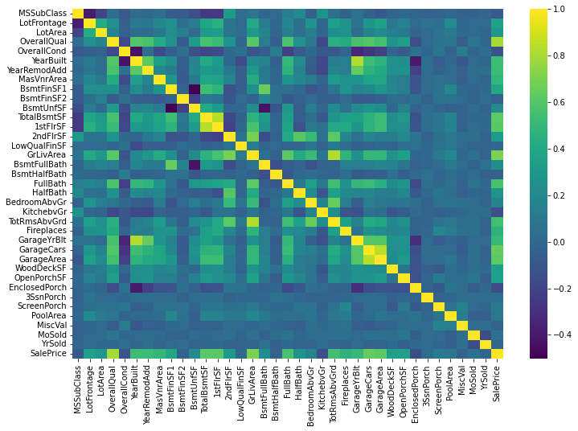

```python
plt.figure(figsize=(12,8))
sns.heatmap(df_numerical.corr(), cmap='viridis')
```

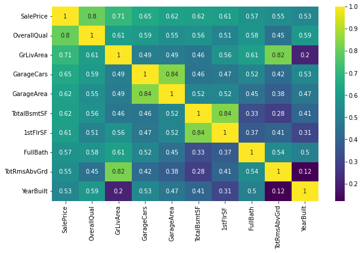

```python
 #saleprice correlation matrix
k = 10 #number of variables for heatmap
cols = df_numerical.corr().nlargest(k, 'SalePrice')['SalePrice'].index
cm = df_numerical[cols].corr()
plt.figure(figsize=(10,6))
sns.heatmap(cm, annot=True, cmap = 'viridis')
```

### Observations:

- Some of the most highly correlated variables are:
  - Overall quality and Sale Price
  - Garage Area and Garage Cars
  - Total Rooms above Ground and Above Ground Living Area
  - 1st Floor Sqft and Total Basement Sqft

### 3.d Pair plot for distribution and density

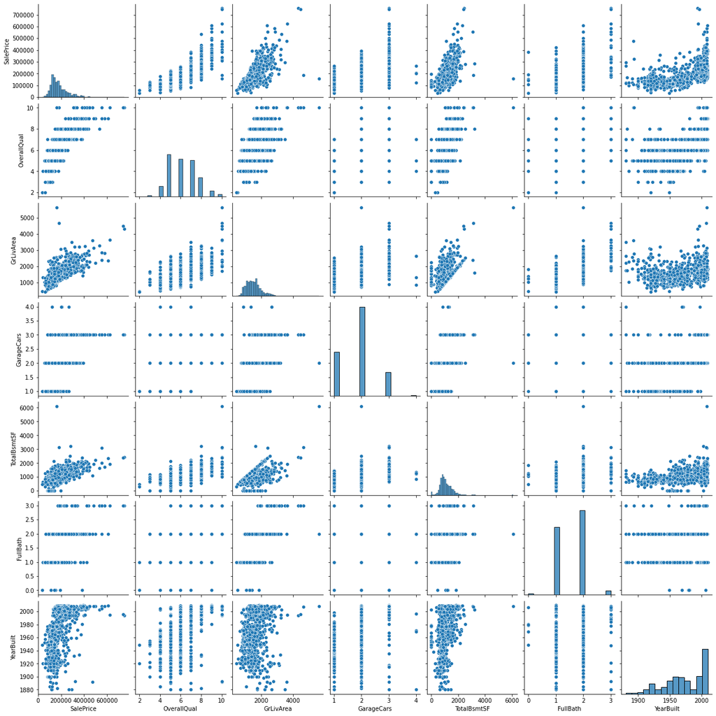

```python
# Visualizing relations between all major variables
cols = ['SalePrice', 'OverallQual', 'GrLivArea', 'GarageCars', 'TotalBsmtSF', 'FullBath', 'YearBuilt']
sns.pairplot(df_numerical[cols])
```

## 4. EDA of Catergorical Variables

### 4.a Missing Value Treatment

```python
df_categorical.isna().sum()
```

```
Heating             0
Foundation          0
SaleCondition       0
Fence            1179
BsmtFinType2       38
LotShape            0
Alley            1369
GarageQual         81
GarageCond         81
MiscFeature      1406
LotConfig           0
Exterior1st         0
GarageType         81
Street              0
BsmtExposure       38
Neighborhood        0
CentralAir          0
KitchenQual         0
FireplaceQu       690
RoofMatl            0
MSZoning            0
PoolQC           1453
ExterCond           0
Exterior2nd         0
Condition2          0
BsmtQual           37
SaleType            0
Electrical          1
Condition1          0
MasVnrType          8
LandSlope           0
RoofStyle           0
BsmtCond           37
BsmtFinType1       37
LandContour         0
Functiol            0
BldgType            0
Utilities           0
PavedDrive          0
HeatingQC           0
GarageFinish       81
ExterQual           0
HouseStyle          0
dtype: int64
```

```python
for col in df_categorical:
    null_vals = df_categorical[col].isna().sum(axis=0)
    if null_vals:
        print(col, " has ", null_vals, " null value(s)")
```

```
Fence  has  1179  null value(s)
BsmtFinType2  has  38  null value(s)
Alley  has  1369  null value(s)
GarageQual  has  81  null value(s)
GarageCond  has  81  null value(s)
MiscFeature  has  1406  null value(s)
GarageType  has  81  null value(s)
BsmtExposure  has  38  null value(s)
FireplaceQu  has  690  null value(s)
PoolQC  has  1453  null value(s)
BsmtQual  has  37  null value(s)
Electrical  has  1  null value(s)
MasVnrType  has  8  null value(s)
BsmtCond  has  37  null value(s)
BsmtFinType1  has  37  null value(s)
GarageFinish  has  81  null value(s)
```

### Fill in the missing values with NA which is what they should have been accoridng to the data description file

```python
for col in df_categorical:
    null_vals = df_categorical[col].isna().sum(axis=0)
    if null_vals:
        df_categorical[col] = df_categorical[col].fillna('NA')
```

```python
for col in df_categorical:
    null_vals = df_categorical[col].isna().sum(axis=0)
    if null_vals:
        print(col, " has ", null_vals, " null value(s)")
```